# Lista 4 - Métodos Quantitativos - IPOL

03/12/2020

## A Base de Dados: U.S. State Constitutions Dataset

O Banco de Dados **“US State Constitutions Dataset”**, criado por Julia Gervaise-Rubicam Clouse (CLOUSE, 2019), converte textos constitucionais (historicos e atuais) dos estados dos EUA para dados quantificáveis utilizando-se da categorização destes textos. O objetivo é analisar a evolução das ideias e prioridades políticas nos 50 estados do país, e analisar a mudança constitucional dos estados ao longo do tempo.

## Analisando a Base

O objetivo dessa análise é fazer uma exploração dos dados a partir de três variáveis: **Lesislative**, **Executive**, e **Judicial**. Respectivamente, tratam do texto que descreve as funções, procedimentos, poderes e limitações da legislatura; do texto que descreve as funções, estrutura, poderes e limitações do Poder Executivo; e do texto que descreve as funções e poderes dos sistemas de tribunais estaduais e dos funcionários do Poder Judiciário (CLOUSE, 2019).

## Criação do índice e justificativa teórica

## Índice de Mudança Proporcional dos Poderes

\[ imp_e = executive/powers \]

\[ imp_l = legislative/powers \]

\[ imp_j = judicial/powers \]

## Índice de Mudança Proporcional dos Poderes

ONDE:

- IMP = Índice de Mudança Proporcional dos Poderes
- imp_e = Índice de Mudança Proporcional do Poder Executivo
- imp_l = Índice de Mudança Proporcional do Poder Legislativo
- imp_j = Índice de Mudança Proporcional do Poder Judiciário
- executive, legislative e judicial = quantidade de palavras destinada respectivamente às categorias “Executive”, “Legislative” e “Judicial” em cada constituição
- powers = somatório das palavras destinadas aos três poderes - Executivo + Legislativo + Judiciário - em cada constituição

## Sobre o Índice de Mudança Proporcional dos Poderes

O Objetivo deste índice é fornecer medida de porporção de cada um dos poderes em relação ao total dedicado aos três em cada constituição adotada ou emendada pelos 50 estados. Deste modo, espera-se observar se existe proporcionalidade entre eles, ou seja, se há um equilíbrio, necessário ao mecanismo de Checks and Balances, ou se a presença (aqui entendida como o número de palavras dedicadas a eles) de cada um dos poderes nas constituições foi se alterando ao longo do tempo de forma desigual.

## Justificativa teórica

A literatura (CLOUSE, 2019) aponta que as primeiras constituições estaduais estadunidenses tendiam a focar nos ramos Legislativo e Exectuivo, enquanto as atuais se concentram em outras, como a de Justiça (CLOUSE, 2019). Conforme texto da autora:

“In general, the constitutions have become less structural documents, establishing fundamental law, and are now vehicles for actively promoting legislative laws and policy initiatives” (CLOUSE, 2019, p. 44).

## Instalando pacotes a serem utilizados para criação do índice

```r
library(tidyverse)
library(readxl)
library(magrittr)
library(dplyr)
library(ggplot2)
library(knitr)
library(rmarkdown)
```

## Carregando as bases de dados: state_const (U.S. State Constitutions) e States and Abbreviations (abreviações dos estados norte-americanos)

```r
state_const <- read_excel("state_const.xlsx")
States_and_Abbreviations <- read_xlsx("States and Abbreviations.xlsx")
```

## Criação dos índices com as bases

```r
constituicoes_poderes <- state_const %>%
  ##criando um novo data frame com as manipulações
  select(state, constitution_year,current_constitution,
         total_words, legislative, executive, judicial) %>% ##selecionando as variáveis de interesse
  left_join(States_and_Abbreviations, constituicoes_poderes, by = "state") %>%
##criando uma nova coluna de abreviacoes a partir do data.frame States and Abbreviations
   mutate (poderes = (legislative + executive + judicial), ##criando uma nova coluna com os valores somados das categorias executivo, legislativo e judiciário
          imp_l = (legislative/poderes),
##criando o índice de mudança proporcional do legislativo em relação à soma dos poderes
          imp_e = (executive/poderes),
##criando o índice de mudança proporcional do executivo em relação à soma dos poderes
          imp_j = (judicial/poderes))
##criando o índice de mudança proporcional do judiciário em relação à soma dos poderes
```

## Visualizando em tabela

```r
paged_table (constituicoes_poderes)
```

| state | constitution_year | current_constitution | total_words | legislative | executive | judicial | abbreviation | poderes | imp_l | imp_e | imp_j |
| --- | --- | --- | --- | --- | --- | --- | --- | --- | --- | --- | --- |
| Alabama | 1819 | 0 | 9877 | 1183 | 1209 | 1345 | AL | 3737 | 0.31656409 | 0.32352154 | 0.35991437 |
| Alabama | 1861 | 0 | 9660 | 1144 | 1238 | 1497 | AL | 3879 | 0.29492137 | 0.31915442 | 0.38592421 |
| Alabama | 1865 | 0 | 8242 | 1245 | 1187 | 1406 | AL | 3838 | 0.32438770 | 0.30927566 | 0.36633663 |
| Alabama | 1867 | 0 | 10861 | 1124 | 1228 | 1597 | AL | 3949 | 0.28462902 | 0.31096480 | 0.40440618 |
| Alabama | 1875 | 0 | 14844 | 1773 | 1593 | 2062 | AL | 5428 | 0.32663965 | 0.29347826 | 0.37988209 |
| Alabama | 1901 | 0 | 28361 | 2243 | 2574 | 3253 | AL | 8070 | 0.27794300 | 0.31895911 | 0.40309789 |
| Alabama | 2016 | 1 | 339576 | 4408 | 2503 | 5606 | AL | 12517 | 0.35216106 | 0.19996804 | 0.44787090 |
| Alaska | 1956 | 0 | 13405 | 821 | 1261 | 975 | AK | 3057 | 0.26856395 | 0.41249591 | 0.31894014 |
| Alaska | 2004 | 1 | 13531 | 936 | 1330 | 1080 | AK | 3346 | 0.27973700 | 0.39748954 | 0.32277346 |
| Arizona | 1912 | 0 | 21091 | 904 | 757 | 3012 | AZ | 4673 | 0.19345174 | 0.16199444 | 0.64455382 |

[output cut: 193 more lines]

## TESTE DE CONFIANÇA - Alpha de Cronbach

```r
library(psych) #baixando o pacote psych
 tabela_para_alpha <- constituicoes_poderes %>%
#criando um novo dataframe
  select(imp_l, imp_e, imp_j)
#selecionando as variáveis de interesse para medir a covariancia
```

## TESTE DE CONFIANÇA - Alpha de Cronbach

```r
psych::alpha(tabela_para_alpha, check.keys = TRUE)
```

```
##
## Reliability analysis
## Call: psych::alpha(x = tabela_para_alpha, check.keys = TRUE)
##
##   raw_alpha std.alpha G6(smc) average_r S/N   ase mean  sd median_r
##       0.83      0.83    0.55      0.62 4.9 0.015 0.36 0.1     0.78
##
##  lower alpha upper     95% confidence boundaries
## 0.8 0.83 0.86
##
##  Reliability if an item is dropped:
##        raw_alpha std.alpha G6(smc) average_r  S/N alpha se var.r med.r
## imp_l       0.85      0.90    0.81      0.81 8.75    0.016    NA  0.81
## imp_e       0.82      0.88    0.78      0.78 7.03    0.020    NA  0.78
## imp_j-      0.42      0.42    0.27      0.27 0.74    0.081    NA  0.27
##
##  Item statistics
##          n raw.r std.r r.cor r.drop mean    sd
## imp_l  203  0.78  0.79  0.54   0.61 0.28 0.095
## imp_e  203  0.81  0.80  0.56   0.64 0.31 0.102
## imp_j- 203  1.00  1.00  0.83   1.00 0.48 0.157
```

```r
#aplicando a função "alpha" do pacote psych
##(os dois pontos :: demonstram para o R qual é o pacote a retirar a função)
```

## TESTE DE CONFIANÇA - Alpha de Cronbach

```r
alpha1 <- psych::alpha(tabela_para_alpha, check.keys = TRUE)
```

```
## Number of categories should be increased  in order to count frequencies.
```

```
## In factor.stats, the correlation matrix is singular, an approximation is used
```

```
## In smc, smcs < 0 were set to .0
```

```
## In smc, smcs < 0 were set to .0
```

## Visualização dos dados

## GRÁFICO 1 - Poderes por ano constitucional

```r
constituicoes_poderes %>%
  ggplot(aes(x = constitution_year,
             y = poderes)) + #determinando os eixos x e y
  geom_point(aes(color = abbreviation)) +
  #determinando a cor por abreviacao/estado
  theme_classic() #deixando clean
```

## GRÁFICO 1 - Poderes por ano constitucional

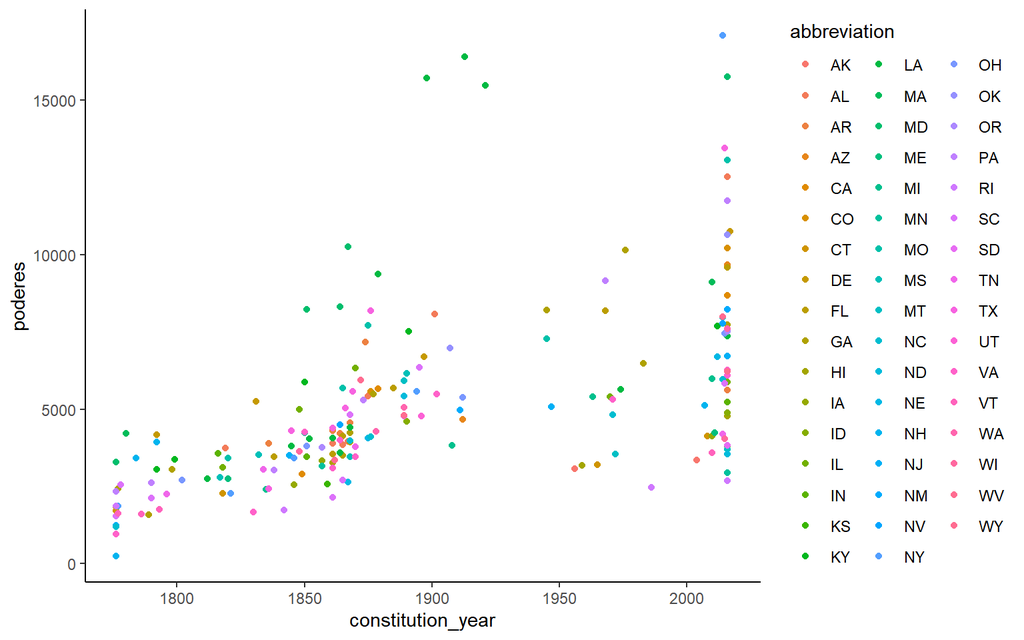

## GRÁFICO 2 - IMPs por ano constitucional

```r
library(viridis)
#incluindo pacote para outras opçõe de escalas de cores

constituicoes_poderes_grafico5 <- constituicoes_poderes %>%
select(constitution_year, abbreviation, imp_l, imp_e, imp_j) %>% #selecionando as variáveis de interesse
  pivot_longer(cols=3:5, names_to = "indices", values_to = "valores")
#pivotando os dados para poder plotar os 3 indices

constituicoes_poderes_grafico5 %>%ggplot(aes(x= constitution_year, y= valores, group=indices, color=indices)) +
#determinando eixos x, y e as linhas do grafico para cada um dos indices
  geom_line() + #ordenando as observações a partir do eixo x
  geom_point() +
#inserindo pontos nas linhas do gráfico apra marcar as mudanças
  facet_wrap(~ abbreviation) +
#separando por estado
  scale_color_viridis(discrete = TRUE, begin=0, end=0.8) +
# definindo escala de cores das linhas dos gráficos e ajustando com begin e end para que a paleta de cores fiquem mais fortes e menos suaves
  scale_y_continuous(breaks = c(0.00, 0.40, 0.80)) +
#definindo as escalas do eixo y
    theme_classic() +
#tema clássico para ficar mais clean
    labs(title = "Indices por ano constitucional e estado", #determinando os marcadores dos gráficos
       y = "Valores dos indices", x="Ano da Constituição") +
     theme(axis.text.x = element_text(size = 6, angle=90, hjust=1),
#rotacionando o eixo x para melhorar a visualização das datas
        axis.text.y = element_text(size = 6),
        axis.title.x = element_text(size = 10),
        axis.title.y = element_text(size = 10))
```

```r
#determinando o tamanho das fontes dos labels
```

## GRÁFICO 2 - IMPs por ano constitucional

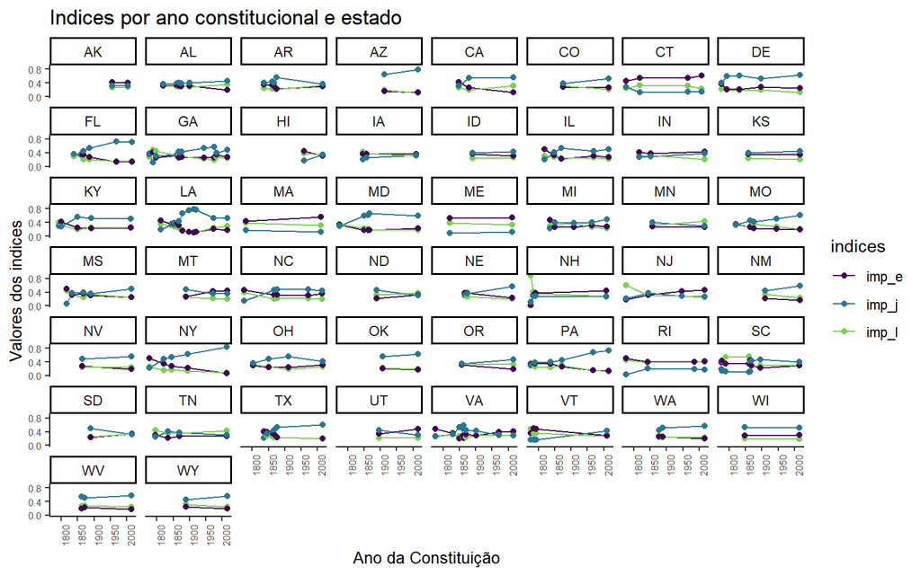

## GRÁFICO 3 - Poderes por ano constitucional separado por estado

```r
constituicoes_poderes %>%
  ggplot(aes(constitution_year, poderes)) +
#selecionando os eixos ano da constituicao e da variavel de interesse (poderes)
  geom_line(color = "steelblue", size = 1) +
#determinando a cor e tamanho da linha
  geom_point(color = "steelblue") +
#determinando a cor do ponto
  labs(title = "Poderes pelo ano da Constituição",
#determinando os labels
       y = "Poderes", x="Ano da Constituição") +
  facet_wrap(~ abbreviation) +
#separando por estado
  scale_y_continuous(breaks = c(0, 7500, 15000)) +
#definindo as escalas do eixo y
  theme_classic() +
     theme(axis.text.x = element_text(size = 6, angle=90, hjust=1),
#rotacionando o eixo x para melhorar a visualização das datas
        axis.text.y = element_text(size = 6),
        axis.title.x = element_text(size = 10),
        axis.title.y = element_text(size = 10))
```

```r
#definindo o tamanho das fontes dos textos dos eixos
```

## GRÁFICO 3 - Poderes por ano constitucional separado por estado

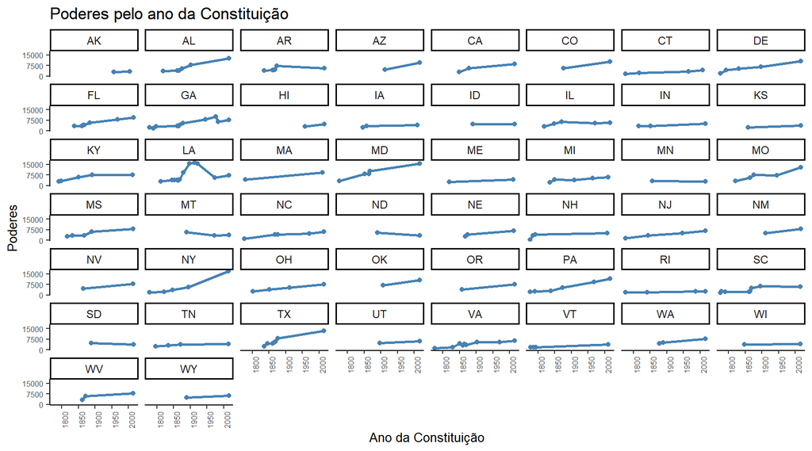